# Tutorial 9.1: Kruskal-Wallis in the lettuce dataset

# 1 The lettuce dataset

In a previous tutorial, we analysed the dataset on lettuce plants with ANOVA. However, it was not clear if all the assumptions of ANOVA were met. Indeed, with only 7 datapoints per group, it is very hard to assess the assumptions of normality and equal variances.

Therefore, we will re-analyse the dataset by using the non-parametric alternative to ANOVA, the Kruskal-Wallis test, which is the right thing to do if we the assumptions are not met.

We will first give a concise overview of what we saw in the ANOVA analysis, which can be found in the “ANOVA_lettuce_plants.Rmd” file.

The researchers want to find out if biochar, compost and a combination of both biochar and compost have an influence on the growth of lettuce plants. To this end, they grew up lettuce plants in a greenhouse. The pots were filled with one of four soil types;

1. Soil only (control)
2. Soil supplemented with biochar (refoak)
3. Soil supplemented with compost (compost)
4. Soil supplemented with both biochar and compost (cobc)

The dataset `freshweight_lettuce.txt` contains the freshweight (in grams) for 28 lettuce plants (7 per condition). The researchers want to use an ANOVA test to find out whether or not there is an effect of one or more of the treatments on the growth of lettuce plants. If so, they will use a post-hoc test (Tuckey test) to find which specific treatments have an effect.

Load the required libraries

```r
library(tidyverse)
library(car)
library(coin)
```

# 2 Data import

```r
lettuce <- read_csv("https://raw.githubusercontent.com/GTPB/PSLS20/master/data/freshweight_lettuce.txt")
## Take a glimpse at the data
glimpse(lettuce)
```

```
## Observations: 28
## Variables: 3
## $ id          <dbl> 1, 2, 3, 4, 5, 6, 7, 8, 9, 10, 11, 12, 13, 14, 15, 16, 17…
## $ treatment   <chr> "control", "control", "control", "control", "control", "c…
## $ freshweight <dbl> 38, 34, 41, 43, 43, 29, 38, 59, 64, 57, 56, 50, 64, 62, 3…
```

```r
## treatment to factor
lettuce$treatment <- as.factor(as.character(lettuce$treatment))
```

# 3 Data exploration

```r
## Count the number of observations per treatment
table(lettuce$treatment)
```

```
##
##    cobc compost control  refoak
##       7       7       7       7
```

Now let’s make a boxplot displaying the freshweight of each treatment condition:

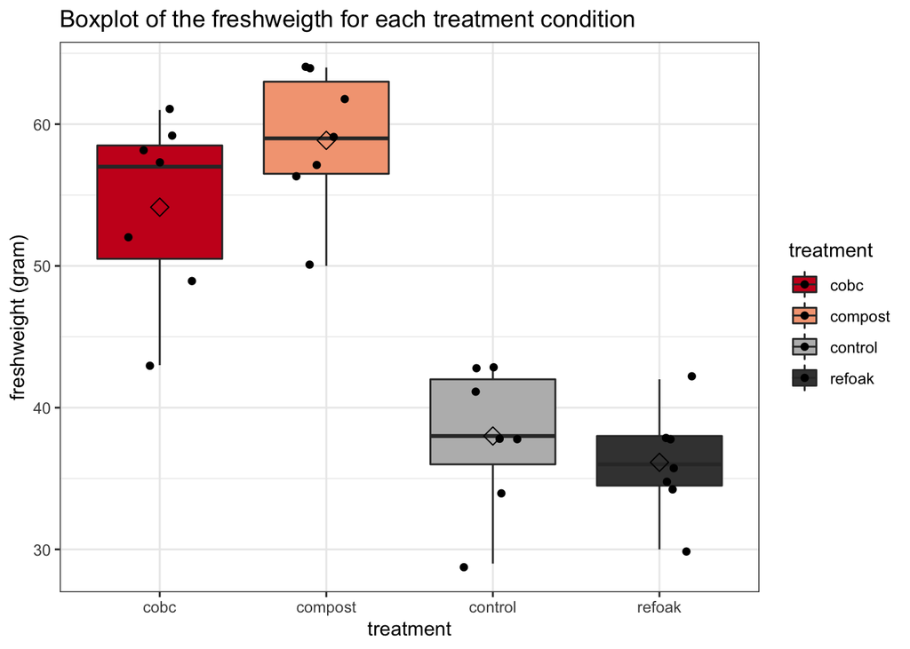

```r
lettuce %>%
  ggplot(aes(x=treatment,y=freshweight,fill=treatment)) +
  scale_fill_brewer(palette="RdGy") +
  theme_bw() +
  geom_boxplot(outlier.shape=NA) +
  geom_jitter(width = 0.2) +
  ggtitle("Boxplot of the freshweigth for each treatment condition") +
  ylab("freshweight (gram)") +
  stat_summary(fun.y=mean, geom="point", shape=5, size=3, color="black", fill="black")
```

## 3.1 Checking the assumptions of ANOVA

To study whether or not the observed difference between the average freshweight values of the differentt treatment groups are significant, we may perform an ANOVA.

The null hypothesis of ANOVA states that: The mean freshweigth is equal between the different treatment groups.

The alternative hypothesis of ANOVA states that: The mean freshweigth for at least one treatment group is different than the mean freshweight in at least one other treatment group.

Before we may proceed with the analysis, we must make sure that all assumptions for ANOVA are met. ANOVA has three assumptions:

1. The observations are independent of each other (in all groups)
2. The data (freshweigth) must be normally distributed (in all groups)
3. The variability within all groups is similar

### 3.1.1 Assumption of independence

The first assumption is met; we started of with 28 lettuce plants and we randomly submitted them to one of four treatment conditions. There is no reason to believe that the plants display systematic differences between ttreatment groups, other than the actual treatment.

### 3.1.2 Assumption of normality

For the second assumption, we must check normality in each group.

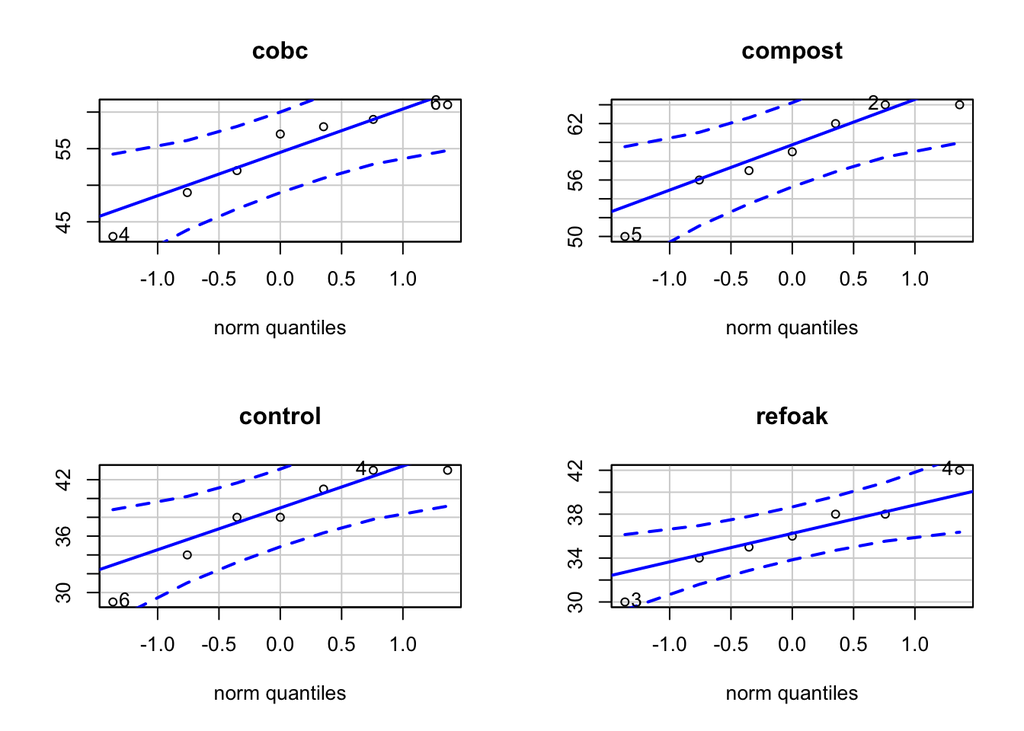

```r
## get qqplots for each individual treatment group
par(mfrow = c(2,2))
for(i in levels(lettuce$treatment)){
  qqPlot(subset(lettuce,treatment == i)$freshweight, main = i, ylab = "")
}
```

While in the “ANOVA_lettuce_plants.Rmd” file we accepted the assumption of normality, it must be noted that it is tricky to assess the assumption with only 7 datapoints. See “ANOVA_lettuce_plants.Rmd” for more details on this.

**Let’s say that here we decide not to assume normality.**

### 3.1.3 Assumption of equal variances

We can check the assumption of equal variance with a boxplot:

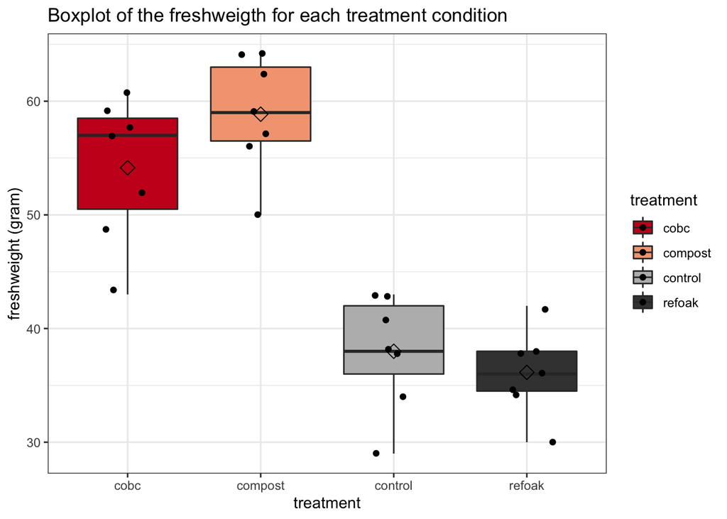

```r
lettuce %>%
  ggplot(aes(x=treatment,y=freshweight,fill=treatment)) +
  scale_fill_brewer(palette="RdGy") +
  theme_bw() +
  geom_boxplot(outlier.shape=NA) +
  geom_jitter(width = 0.2) +
  ggtitle("Boxplot of the freshweigth for each treatment condition") +
  ylab("freshweight (gram)") +
  stat_summary(fun.y=mean, geom="point", shape=5, size=3, color="black", fill="black")
```

As a measure of variability, we may take the height of each boxplot’s box. This is the interval between the 25% and 75% quantile. Here we can see that this interval, as well as the length of the whiskers, is approximately equal for most groups. However, the variability of cobc does seem to be quite a bit larger than the variability in the refoak group.

**While we accepted the assumption of equal variances in the** **“ANOVA_lettuce_plants.Rmd” file, we will here reject the** **assumption.**

Not all assumptions for ANOVA are met. As such, we will rely on the non-paramettric alternative of ANOVA: the Kruskal-Wallis test.

# 4 Analysis

## 4.1 Kruskal-Wallis rank test

If we want to test for a difference in the median of the different treatment groups, we have to ** assume a location shift **, saying that all treatment groups follow the same distribution, but with a different median.

However, here, we might be ** not prepared for taking this assumption **. While the range and spread of the data is similar for most groups (see boxplot), there is a quite a big difference between the IQR of the refoak and cobc conditions.

When we reject the assuming tthe location shift, we can relax the distributional assumptions even further and perform a test in terms of probabilistic indices (see the “Non_parametric_shrimps.Rmd” file).

With this Kruskal-Wallis test, we will test whether or not the chance that a random value of one treatment group is larger than or equal to (“$\geq$”) a random value of another treatment group is significantly different from 50%.

### 4.1.1 Hypotheses

- Null hypothesis: $H0$: The distribution of freshweights of lettuce plants are equal for all treatment conditions.
- Alternative hypothesis: $HA$: The chance that a random value of at least one treatment group is larger than or equal to (“$\geq$”) a random value of at least one other treatment group is significantly different from 50%.

### 4.1.2 test

```r
set.seed(1)
kwPerm <- kruskal_test(freshweight~treatment,lettuce,
                       distribution=approximate(nresample=100000))
kwPerm
```

```
##
##  Approximative Kruskal-Wallis Test
##
## data:  freshweight by
##   treatment (cobc, compost, control, refoak)
## chi-squared = 20.715, p-value < 1e-05
```

We find an extremly significant (p < 1e-05) of the treatment on the freshweight. On the 5% global significance level, we may state that the chance that a random value of at least one treatment group is larger than or equal to (“$\geq$”) a random value of at least one other treatment group is significantly different from 50%.

Now, we will perform a post-hoc analysis to find out which specific groups are different from each other.

## 4.2 Post-hoc analysis

We will perform a post-hoc analysis with pairwise Wilcoxon rank sum test. As we did not want to assume the location shift, we will interpret the outcome in terms of probabilistic indices. Note that after the analysis, we will need to correct the acquired p-values for multiple testing.

For each pairwise test, we have the following hypotheses:

- Null hopothesis: $H0$: The distribution of freshweights of lettuce plants are equal for both treatment conditions.
- Alternative hypothesis: $HA$: The chance that a random value of treatment group 1 is larger than or equal to (“$\geq$”) a random value of treatment group 2 is significantly different from 50%.

```r
## initial attempt to perform the analysis
pairwise.wilcox.test(lettuce$freshweight,lettuce$treatment)
```

[output not shown]

```
##
##  Pairwise comparisons using Wilcoxon rank sum test
##
## data:  lettuce$freshweight and lettuce$treatment
##
##         cobc  compost control
## compost 0.400 -       -
## control 0.013 0.013   -
## refoak  0.013 0.013   0.400
##
## P value adjustment method: holm
```

We get the following warning message: `cannot compute exact p-value with ties`.

This is because the `pairwise.wilcox.test()` use the standard `wilcox.test()` function. In the help file of this function (?wilcox.test), we can read that in the presence of ties in the data, the function will perform a asymptotic test rather than an exact test.

If we do want to obtain exact p-values, we may use the `wilcox_test()` function from the `coin` package for each pairwise combination of treatments. The obtained p-values must be corrected for multiple testing, e.g. with the `p.adjust()` function.

```r
## caluclate the p-value for each treatment combination with wilcoxon_test
treatments <- levels(lettuce$treatment)
freshweight <- lettuce$freshweight

pvalues <- combn(treatments,2,function(x){

  ## Pairwise Wilcon test
  test = wilcox_test(freshweight~treatment,subset(lettuce,treatment%in%x), distribution = 'exact')

  ## Get and store p-value of test
  pvalue(test)
})

## Adjust for multiple testing
pvalues_holm = p.adjust(pvalues,method = 'holm')

## link the p-value with the correct pairwise test
names(pvalues_holm) <- combn(levels(lettuce$treatment),2,paste,collapse="_VS_")
pvalues_holm
```

```
##    cobc_VS_compost    cobc_VS_control     cobc_VS_refoak compost_VS_control
##        0.393939394        0.005244755        0.003496503        0.003496503
##  compost_VS_refoak  control_VS_refoak
##        0.003496503        0.405594406
```

The exact p-values do indeed deviate from those calculated with the `pairwise.wilcox.test()` function. We will proceed with the exact p-values.

Now we will compute the point estimation for the probabilistic index (for each pairwise comparison). Note that we already did this in the “Non_parametric_shrimps.Rmd” and “Non_parametric_NHANES.Rmd” file for a single comparison.

```r
## Count the number of observations per group
nGroup <- table(lettuce$treatment)

## Compute the probabilistic index for each pairwise combination
treatments <- levels(lettuce$treatment)

probInd <- combn(treatments,2,function(x){
  ## Compute the U1 statistic
  U1 <- wilcox.test(freshweight~treatment,subset(lettuce,treatment%in%x))$statistic

  ## Compute the probabilistic index
  U1/prod(nGroup[x])
})
```

```
## Warning in wilcox.test.default(x = c(59, 64, 57, 56, 50, 64, 62), y = c(38, :
## cannot compute exact p-value with ties
```

```
## Warning in wilcox.test.default(x = c(38, 34, 41, 43, 43, 29, 38), y = c(38, :
## cannot compute exact p-value with ties
```

```r
## link the probabilistic index with the correct pairwise test
names(probInd) <- combn(levels(lettuce$treatment),2,paste,collapse="_VS_")
probInd
```

```
##    cobc_VS_compost    cobc_VS_control     cobc_VS_refoak compost_VS_control
##          0.2857143          0.9795918          1.0000000          1.0000000
##  compost_VS_refoak  control_VS_refoak
##          1.0000000          0.6428571
```

We again see the same warning message. Here, this is not a prblem, we are not interested in the p-values (which we already computed), we only care about the probabilistic indices, that are calculated from the U1 statistic. U1 is computed as the number of times an observation of group 1 is larger than or equal to an observation of group 2. This statistic is thus defined even in the case of ties.

# 5 Conclusion

We find an extremly significant (p < 1e-05) of the treatment on the freshweight. On the 5% global significance level, we may state that the chance that a random value of at least one treatment group is larger than or equal to (“$\geq$”) a random value of at least one other treatment group is significantly different from 50%.

For the post-hoc analysis:

For the other contrast, we do not enough find evidence to suggest significant differences between the treatment groups.

We may conclude that supplementing soil with compost or with both compost and biochar has a positive effect on the freshweigth of lettuce plants. Note that, qualitatively, these conclusion are exactly the same as with the ANOVA analysis of the dataset in the “ANOVA_lettuce_plants.Rmd” file.

# [Home](https://gtpb.github.io/PSLS20/)